# Simplest Example - 1D Parameter Search

# Observed Data

We will generate normal data and try and pretend it’s from some unknown population. Our goal is to use Bayesian estimation to find the true $\sigma^2$ and $\mu$.

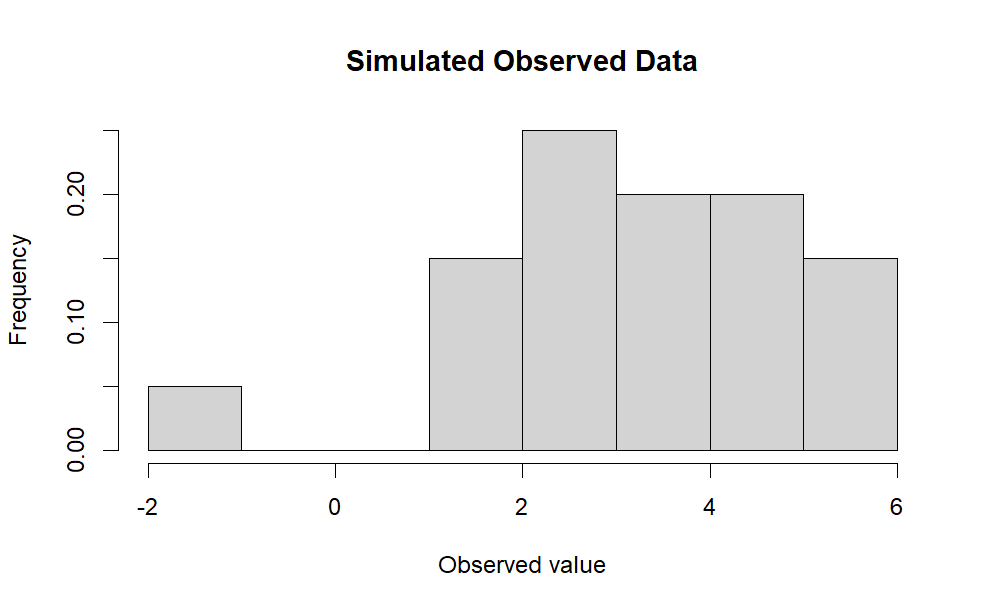

```r
library(ggplot2)
set.seed(68)

n_obs <- 20
true_mu <- 3
true_sigma_sqr <- 4

obs <- rnorm(n_obs, mean=true_mu, sd=sqrt(true_sigma_sqr))
hist(obs, probability = TRUE,
     xlab = "Observed value", main = "Simulated Observed Data",
     ylab = "Frequency")
```

```r
NA
NA
```

At this point we know that this data is following a normal distribution, but we just don’t know the true mean and variance.

# Choosing Priors

We will choose uninformative priors for both our parameters. An uninformative prior is one that has little effect or weight on the out come of our Bayesian model. It’s a bold choice in real world scenarios but for our example it will simplify the math, allowing one to focus on understanding the methodology.

$$\begin{align*}
\sigma^2 \sim &\text{Uniform}[0,1] \\
\mu \sim &\text{Uniform}[0,1] \\
&P(\sigma^2) = 1 \\
&P(\mu) = 1
\end{align*}$$
Again, choosing such a uniform range for $\sigma^2$ is very unrealistic (since it’s highly unlikely your variance will ever equal zero), but it simplifies steps later on.

# Preparing for Gibbs Sampling

To actually perform Gibbs sampling, we need all the conditionals for our unknowns that are pulled from the joint distribution of the proportional.

$$\begin{align*}
\underbrace{P(\vec{\theta}| \vec{X})}_{\text{Posterior}} &\propto
\underbrace{P(\vec{X}|\vec{\theta})}_{Likelihood}
\underbrace{P(\vec{\theta})}_{Priors}\\
\Rightarrow P(\vec{\theta}|\vec{X}) &\propto \underbrace{P(\vec{X},
\vec{\theta})}_{Joint}
\end{align*}$$

## Finding the Joint

First let’s find the priors.

$$\begin{align*}
P(\vec{\theta}) &= P(\mu, \sigma^2) \\
&= P(\mu)P(\sigma^2) \text{ because i.i.d.}\\
&= 1
\end{align*}$$
We also know the pdf of the likelihood, since we are assuming the observed data is normally distributed.

$$\begin{align*}
P(\vec{X}|\vec{\theta}) &= P(X_1, X_2,\ldots,X_n| \mu, \sigma^2) \\
&= \prod^n_{i=1}P(X_i | \mu, \sigma^2) \\
&= \prod^n_{i=1}
\frac{1}{\sqrt{2\pi\sigma^2}}e^{-\frac{(x_i-\mu)^2}{2\sigma^2}} \\
&=(\frac{1}{2\pi\sigma^2})^n \prod^n_{i=1}
e^{-\frac{(x_i-\mu)^2}{2\sigma^2}} \\
&= \underbrace{{2\pi}^{-\frac{n}{2}}}_{\text{Constant}}
(\sigma^2)^{-\frac{n}{2}} \underbrace{e^{-\frac{\sum_{i=1}^{n}
(x_i-\mu)^2}{2\sigma^2}}}_{\text{Power Rules}} \\
&\propto (\sigma^2)^{-\frac{n}{2}} e^{-\frac{\sum_{i=1}^{n}
(x_i-\mu)^2}{2\sigma^2}}
\end{align*}$$

Putting this all together we have:

$$\begin{align*}
P(X, \vec{\theta}) &= P(X, \mu, \sigma^2) \\
&= P(X)P(\mu)P(\sigma^2) \\
&\propto (\sigma^2)^{-\frac{n}{2}} e^{-\frac{\sum_{i=1}^{n}
(x_i-\mu)^2}{2\sigma^2}} \cdot 1 \cdot 1
\end{align*}$$
This represents what our joint is proportional to.

## Finding the Conditionals

So, at this point we now know the pdf for our joint distribution but we still don’t know the values the parameters $\mu$ and $\sigma^2$. We need to explore their parameter spaces with gibbs sampling to converge to what they could be!

Their parameter spaces are defined by the following conditionals,

$$\sigma^2 | \mu, X \\
\mu | \sigma^2, X$$
where X is the observed values.

To find these conditionals we must apply the conditional theorem below:

$$\begin{align*}
P(A| B,C) &= \frac{P(A,B|C)}{P(B|Y)} \\
\Rightarrow P(\sigma^2 | X_1, \ldots, X_n, \mu) &= \frac{P(\mu,
\sigma^2 | X_1, \ldots, X_n)}{\underbrace{P(\mu |X_1, \ldots,
X_n)}_{\text{Constant}}} \propto P(\mu, \sigma^2 | X_1, \ldots, X_n)
\\
P(\mu, \sigma^2 | X_1, \ldots, X_n) &= (\sigma^2)^{-\frac{n}{2}}
e^{-\frac{\sum_{i=1}^{n} (x_i-\mu)^2}{2\sigma^2}}
\end{align*}$$

And a very similar procedure is followed for the $\mu$ conditional.

It’s also important to note our conditionals *must be PDFs*, meaning under the curve must integrate to one. To avoid the stresses of normalization, we can simply try to define our resulting conditionals by known distributions.

### Finding the $\sigma^2$

In this scenario, $\mu$ and $Y$ are constant. We can fit this into the Inverse Gamma Distribution.

$$f_{\text{Inverse Gamma}}(x) =
\frac{\beta^{\alpha}}{\Gamma(\alpha)}x^{-\alpha-1} e^{\frac{-\beta}{x}}$$

Matching the powers of $x$ gives:
$$\begin{align*}
-\alpha-1 &= (\alpha+1) \\
\frac{n}{2} &= \alpha + 1 \\
\frac{n}{2}-1 = \alpha
\end{align*}$$
The $\beta$ is easier to see:

$$\beta = \frac{\sum_{i=1}^n(x_i - \mu)^2}{2} = \frac{\text{SSE}}{2}$$
Putting this together gives:

$$\begin{align*}
P(\sigma^2 | \vec{X}, \mu) &=
\underbrace{\frac{(\frac{\text{SSE}}{2})^{\frac{n}{2}-1}}{\Gamma(\frac{n}{2}-1)}}_{\text{Constant}}(\sigma^2)^{-\frac{n}{2}}
e^{-\frac{\text{SSE}}{2\sigma^2}} \\
& \propto (\sigma^2)^{-\frac{n}{2}}
e^{-\frac{\text{SSE}}{2\sigma^2}} \\
\Rightarrow & \sigma^2 | \vec{X}, \mu \sim
\text{InvGamma}(\frac{n}{2}-1, \frac{SSE}{2})
\end{align*}$$

### Finding $\mu$

Here, we find that $mu \sim N(\bar{x}, \frac{\sigma^2}{n})$, which makes sense since the standard deviation here is the variance of the sample mean and $\mu$ represents our mean. To come to this conclusion, you have to do the following trick:
$$\begin{align*}
\sum^n_{i=1}(y_i - \mu)^2 &= \sum^n_{i=1}[(y_i - \bar{x})^2 +
(\bar{x}-\mu)^2] \\
&= \underbrace{\sum^n_{i=1}(y_i - \bar{x})^2}_{\text{constant}} +
n(\mu-\bar{x})^2 \\
&\propto n(\mu-\bar{x})^2 \\
\Rightarrow P(\mu | \vec{X}, \sigma^2)
&= (\sigma^2)^{-\frac{n}{2}}e^{-\frac{n(\mu-\bar{x})^2}{2\sigma^2}}
\\
&\mu | \vec{X}, \sigma^2 \sim N(\bar{x}, \frac{\sigma^2}{n})
\end{align*}$$
Now we have the two distributions we can sample from to perform our Gibbs Sampling.

## Performing the Gibbs Sampling

First, it’s always easiest to set up the function that actually moves through the parameter space first:

```r
library(invgamma) # required for inverse gamma generation

# constants for calculations
x_bar <- mean(obs)
alpha <- (n_obs/2)-1

# Function returning a SINGLE sample from the parameter space
gibbs_sample <- function(last_mu, last_sigsqr ) { # based on the last one

  new_mu <- rnorm(1, mean=x_bar, sd = last_sigsqr/n_obs)
  new_sigsqr <- rinvgamma(1, shape = alpha, rate = (sum((obs - new_mu)^2))/2)

  return(c(new_mu, new_sigsqr)) # the new sample
}
# I don't think i need both parameter intakes, but it feels unbalanced if i
# remove them
```

Now, we can actually run the simulation:

```r
init_mu <- 50 # where we start
init_sigsqr <- 50

runs <- 5000
samples <- matrix(NA, nrow=runs, ncol=2)

set.seed(68)
for (i in 1:runs) {
  #sampling and saving
  gibber <- gibbs_sample(init_mu, init_sigsqr)
  samples[i,1] <- gibber[1]
  samples[i,2] <-gibber[2]

  # Updating the initalization values
  init_mu <- gibber[1]
  init_sigsqr <- gibber[2]
}
```

A trace plot, showing convergence to the true mu and sigma is shown below:

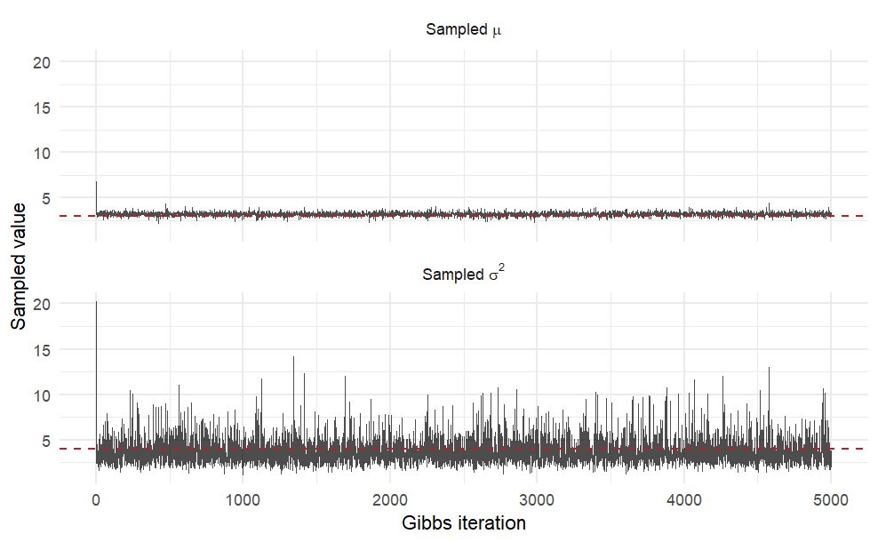

And, just for interest, the parameter space is from the simulation is plotted below:

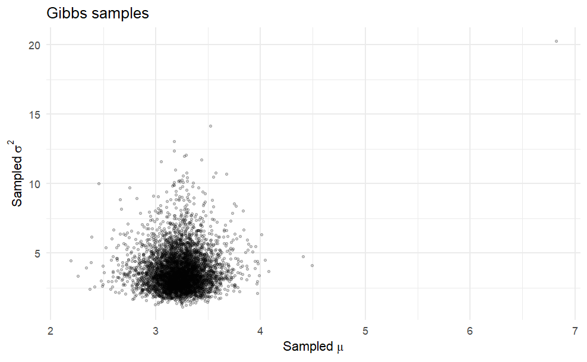

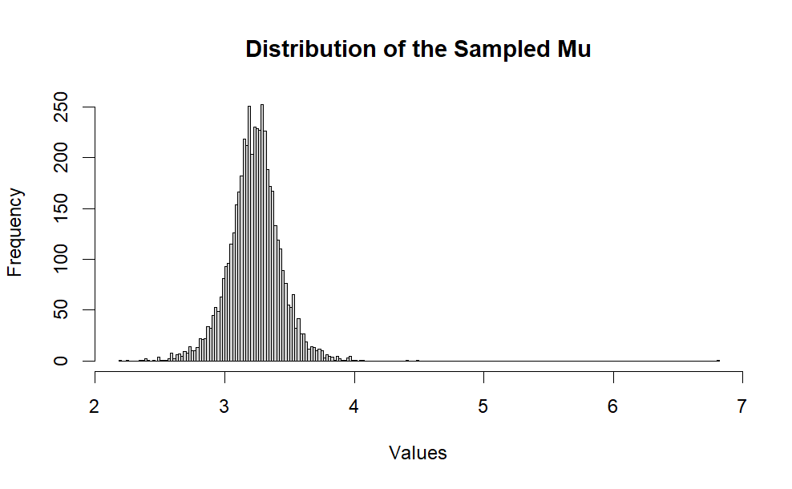

```r
samp_mu <- samples[-500,1]
hist(samp_mu, xlab="Values", ylab="Frequency", main="Distribution of the Sampled Mu", "FD")
```

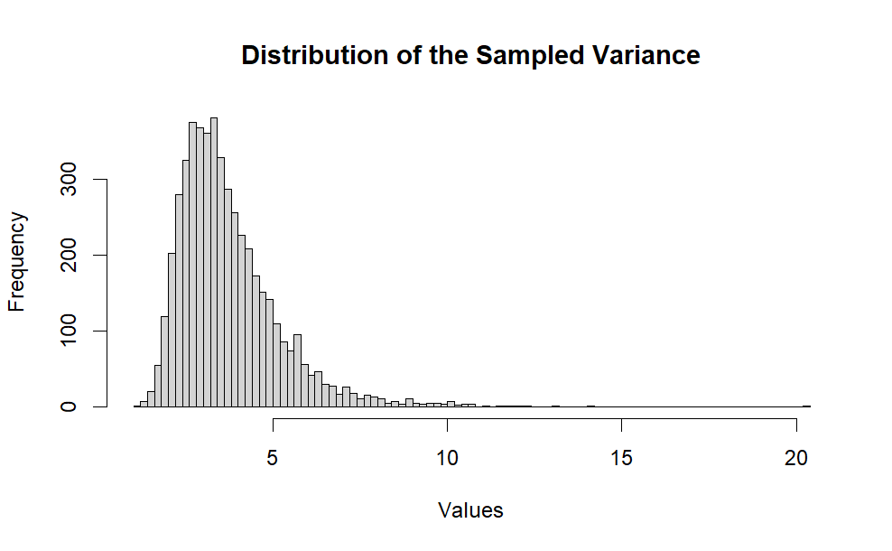

```r
samp_mu <- samples[-500,2]
hist(samp_mu, xlab="Values", ylab="Frequency", main="Distribution of the Sampled Variance", "FD")
```

I think this makes sense? The sampled variance is giving very chi-squared and the mean is normal looking.